# act_report

## Report: act_report

- Create a **250-word-minimum written report** called "act_report.pdf" or "act_report.html" that communicates the insights and displays the visualization(s) produced from your wrangled data. This is to be framed as an external document, like a blog post or magazine article, for example.

### Insights by HADIL

I asked myself when I first began this project, "Am I going to spend hours working on a Twitter account for a dogs?" Dogs are incredibly popular and well-liked! and this became extremely clear once the wrangling was finished and the insights and conclusions were given.

Even that I worked on a very specific part of the dataframe to visual it and give my insights , I believe that are beneficial and so meanigful

We have diffrent dog stage with diffrent values

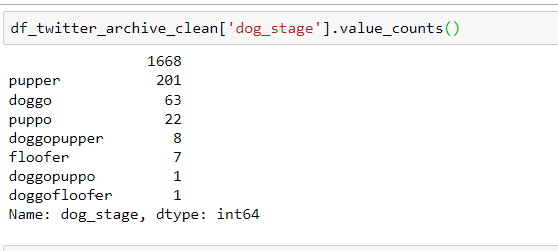

[figure not shown]

As I always find liking a post to be easier and more doable than retweeting it, I decided to base my visualizations on the average number of likes and retweets since I am working on a project where I have the chance to find out if other people feel the same way.

##### Some Limitations:

- the none values for the dog stage column